# Session 21: Assumptions of modeling

In this notebook we will examine the various assumptions made in statistical modeling.

```r
library(ggplot2)
library(dplyr)
library(tidyr)
library(NHANES)
library(cowplot)
library(igraph)
#library('MBESS')

set.seed(123456)
```

First let’s set up a simple linear model using simulated data.

```r
slope=0.4
noiseLevel=1

x=seq(-4,4)
y=x*slope + rnorm(length(x))*noiseLevel
y=y-mean(y)

dataDf=data.frame(x,y)

# we can use the predict() function to predict heights for a new set of ages
# based on the model estimated from the NHANES dataset

save(dataDf,file='simData.Rdata')
```

```r
lmResultSimulated=lm(y~x + 0)
print(lmResultSimulated)
```

```
##
## Call:
## lm(formula = y ~ x + 0)
##
## Coefficients:
##      x
## 0.6293
```

```r
print(summary(lmResultSimulated))
```

```
##
## Call:
## lm(formula = y ~ x + 0)
##
## Residuals:
##     Min      1Q  Median      3Q     Max
## -0.8254 -0.6122 -0.3237  0.8219  1.3234
##
## Coefficients:
##   Estimate Std. Error t value Pr(>|t|)
## x   0.6293     0.1031   6.102 0.000289 ***
## ---
## Signif. codes:  0 '***' 0.001 '**' 0.01 '*' 0.05 '.' 0.1 ' ' 1
##
## Residual standard error: 0.7988 on 8 degrees of freedom
## Multiple R-squared:  0.8231, Adjusted R-squared:  0.801
## F-statistic: 37.23 on 1 and 8 DF,  p-value: 0.0002889
```

Show how we could solve the problem using linear algebra. We use the pseudoinverse:

$$\beta = (X'X)^{-1}X'y$$

This requires matrix multiplication, which we can perform using the %*% operator in R. The matrix transpose (noted by the ’ symbol in the equation) is performed using t() in R.

```r
xmat=as.matrix(x)
ymat=as.matrix(y)
beta_hat = (t(xmat)%*%xmat)^-1*t(xmat)%*%ymat
print(beta_hat)
```

```
##           [,1]
## [1,] 0.6292647
```

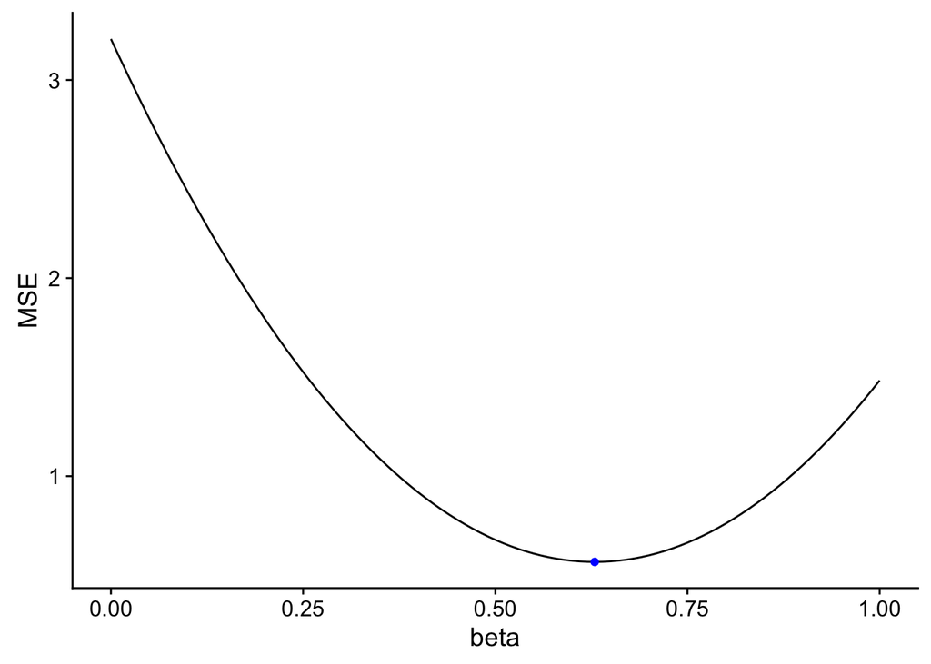

```r
simDf=data.frame(beta=seq(0.0,1.0,0.01))

runLm = function(simDf,dataDf){
  predicted = dataDf$x * simDf$beta
  simDf$MSE=mean((dataDf$y - predicted)**2)
  return(simDf)
}

simDf = simDf %>% group_by(beta) %>% do(runLm(.,dataDf))
dataDf$predicted=predict(lmResultSimulated)
dataDf$residual=lmResultSimulated$residuals

ggplot(simDf,aes(beta,MSE)) +
  geom_line() +
  annotate('point',x=lmResultSimulated$coefficients[1],y=mean(lmResultSimulated$residuals**2),color='blue')
```

Let’s plot the data compared to the model and show the residuals.

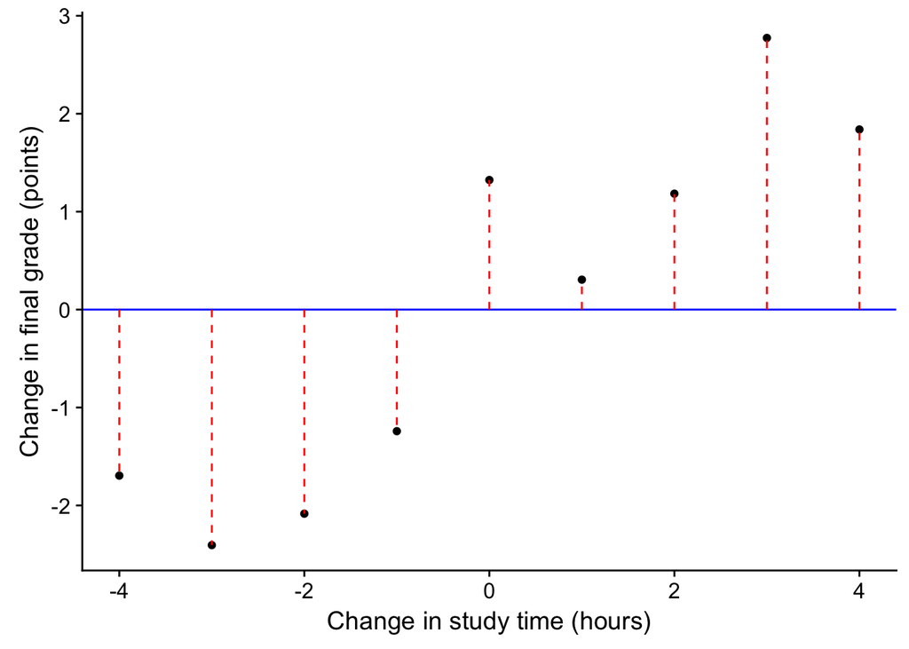

```r
dataDf$predicted=mean(dataDf$y)
dataDf$residual=dataDf$y - mean(dataDf$y)
p=ggplot(dataDf,aes(x,y)) +
  xlab('Change in study time (hours)') +
  ylab('Change in final grade (points)') +
  geom_point() + geom_hline(yintercept = mean(dataDf$y),color='blue')
for (i in 1:dim(dataDf)[1]){
  p=p+annotate('segment',x=dataDf$x[i],xend=dataDf$x[i],
               y=dataDf$predicted[i],yend=dataDf$y[i],color='red',linetype='dashed')
}
print(p)
```

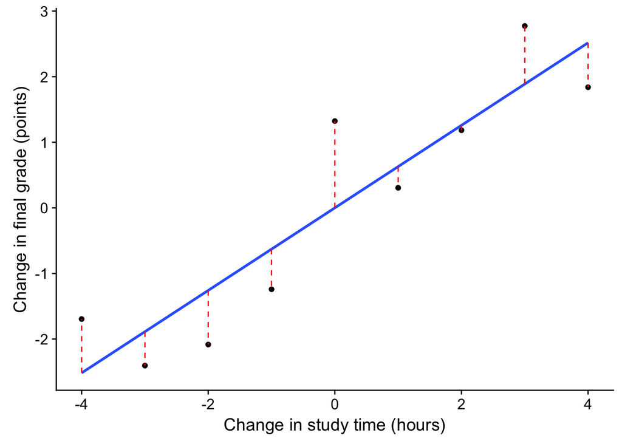

```r
dataDf$predicted=predict(lmResultSimulated)
dataDf$residual=lmResultSimulated$residuals
p=ggplot(dataDf,aes(x,y)) +
  xlab('Change in study time (hours)') +
  ylab('Change in final grade (points)') +
  geom_point() + geom_smooth(method='lm',se=FALSE)
for (i in 1:dim(dataDf)[1]){
  p=p+annotate('segment',x=dataDf$x[i],xend=dataDf$x[i],
               y=dataDf$predicted[i],yend=dataDf$y[i],color='red',linetype='dashed')
}
print(p)
```

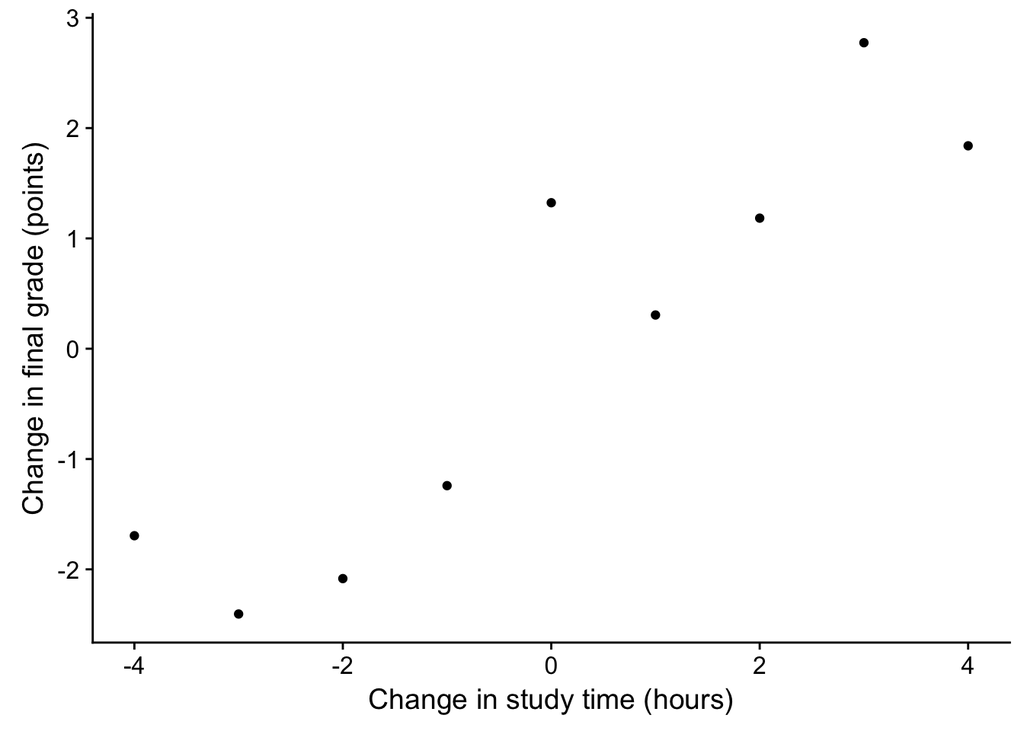

```r
p=ggplot(dataDf,aes(x,y)) +
  geom_point() +
  xlab('Change in study time (hours)') +
  ylab('Change in final grade (points)')
print(p)
```

```r
print('sum of residuals')
```

```
## [1] "sum of residuals"
```

```r
print(sum(dataDf$residual))
```

```
## [1] 2.775558e-16
```

```r
print('mean of squared residuals')
```

```
## [1] "mean of squared residuals"
```

```r
print(mean(lmResultSimulated$residuals**2))
```

```
## [1] 0.5672028
```

We can plot the residuals in a couple of ways, to see what they look like.

First, let’s just plot a histogram of residuals (though in this example there are too few data points for this to make sense).

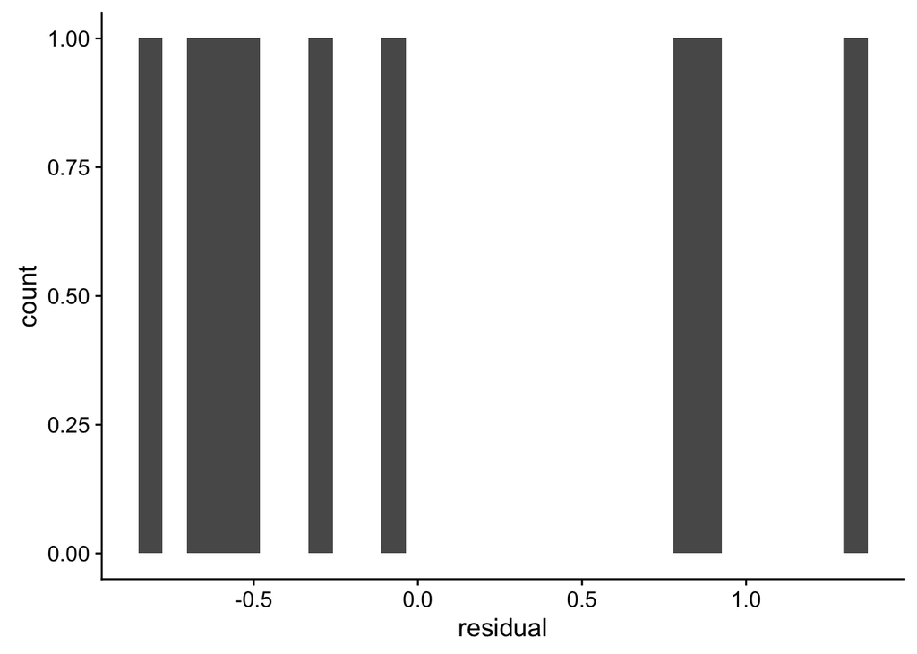

```r
ggplot(dataDf,aes(residual)) +
  geom_histogram()
```

They should be centered around zero and be roughly normally distributed. We can also plot the residuals against age, to see if there is any relationship. We first standardize both variables (i.e. turn them into z-scores).

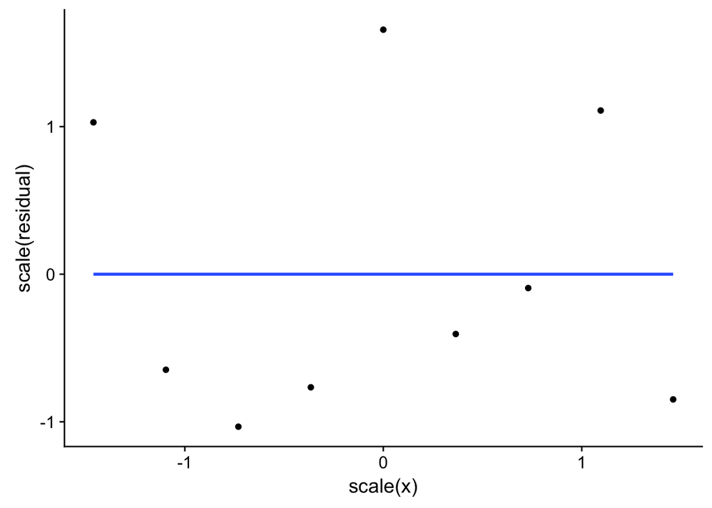

```r
ggplot(dataDf,aes(scale(x),scale(residual))) +
  geom_point() + geom_smooth(method='lm',se=FALSE)
```

Here we don’t see any relationship between age and the residuals - meaning that the model seems to fit equally well across the entire range of ages. This is confirmed by the fact that the line relating age and residuals falls squarely on top of the zero line.

#### Linearity

The data above were generated by a linear model. Now let’s look at what happens with the assumption of linearity is violated; we will create a dataset similar to the one above, but in this case the relation between x and y is nonlinear (quadratic, to be specific).

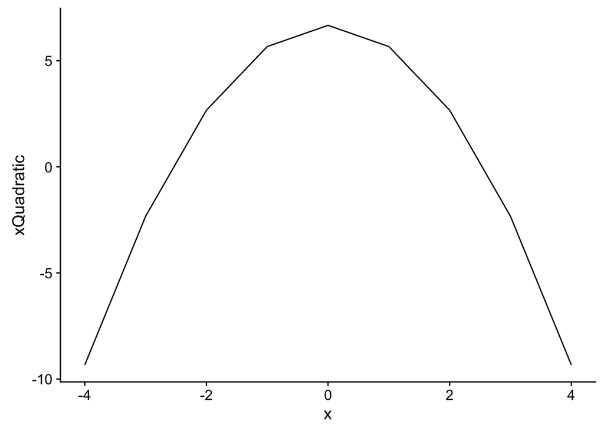

```r
dataDf$xQuadratic=-1*(dataDf$x)**2
dataDf$xQuadratic = dataDf$xQuadratic - mean(dataDf$xQuadratic)
ggplot(dataDf,aes(x,xQuadratic )) +
         geom_line()
```

Now let’s generate some data based on this relationship.

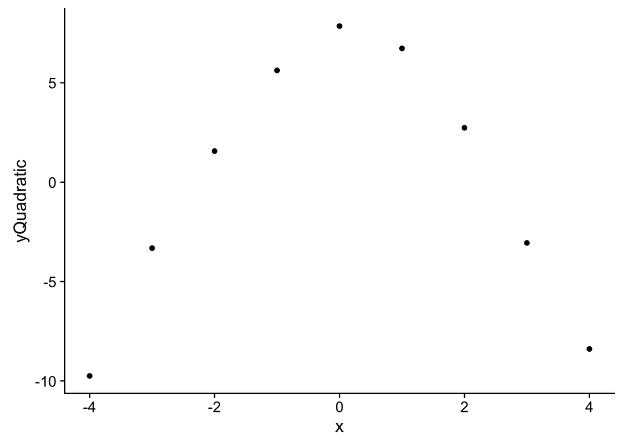

```r
dataDf$yQuadratic = dataDf$xQuadratic + rnorm(nrow(dataDf),sd=noiseLevel)
dataDf$yQuadratic = dataDf$yQuadratic - mean(dataDf$yQuadratic)
ggplot(dataDf,aes(x,yQuadratic )) +
  geom_point()
```

Now you can see that there is pretty clearly a nonlinear relationship between age and height. We call this an “inverted U” relationship.

Now let’s say that we haven’t looked very closely at our data, and we decided to fit a linear model to the data. What happens?

```r
lmResultIncorrectModel=lm(yQuadratic~x + 0,data=dataDf)
print(summary(lmResultIncorrectModel))
```

```
##
## Call:
## lm(formula = yQuadratic ~ x + 0, data = dataDf)
##
## Residuals:
##    Min     1Q Median     3Q    Max
## -9.103 -3.539  1.887  5.784  7.854
##
## Coefficients:
##   Estimate Std. Error t value Pr(>|t|)
## x   0.1610     0.8326   0.193    0.851
##
## Residual standard error: 6.449 on 8 degrees of freedom
## Multiple R-squared:  0.004654,   Adjusted R-squared:  -0.1198
## F-statistic: 0.03741 on 1 and 8 DF,  p-value: 0.8515
```

Now we see that there is no significant relationship between age and height according to the model, even though there clearly is a relationship according to our eye!

Let’s look at the residuals to see if this is evident.

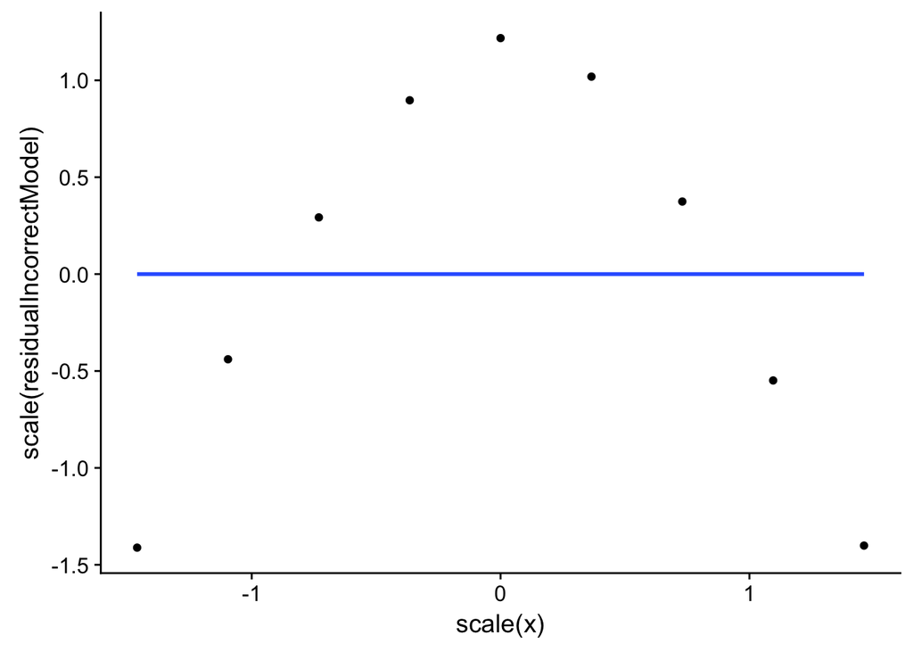

```r
dataDf$residualIncorrectModel=lmResultIncorrectModel$residuals

ggplot(dataDf,aes(scale(x),scale(residualIncorrectModel))) +
  geom_point() + geom_smooth(method='lm',se=FALSE)
```

It’s clear in the plot of residuals versus x that there is somethign going on; even though the line still sits at zero, we can see that the residuals vary systematically with the value of X.

Moral of the story: Always examine residuals.

How could we address this? One way is to explicitly put the nonlinear term into the model. So, instead of:

$$y = x*\beta$$

we could use:

$$y = x*\beta_1 + x^2*\beta_2$$

Let’s fit that model, and look at the results:

```r
dataDf$xSquared = x**2 - mean(x**2)
lmResultQuadraticModel = lm(yQuadratic~ x + xSquared + 0, data=dataDf)
print(summary(lmResultQuadraticModel))
```

```
##
## Call:
## lm(formula = yQuadratic ~ x + xSquared + 0, data = dataDf)
##
## Residuals:
##      Min       1Q   Median       3Q      Max
## -1.13005 -0.42493 -0.06627  0.60169  0.97040
##
## Coefficients:
##          Estimate Std. Error t value Pr(>|t|)
## x         0.16103    0.10275   1.567    0.161
## xSquared -1.03246    0.04535 -22.766 7.99e-08 ***
## ---
## Signif. codes:  0 '***' 0.001 '**' 0.01 '*' 0.05 '.' 0.1 ' ' 1
##
## Residual standard error: 0.7959 on 7 degrees of freedom
## Multiple R-squared:  0.9867, Adjusted R-squared:  0.9829
## F-statistic: 260.4 on 2 and 7 DF,  p-value: 2.687e-07
```

We can plot the predicted response from this more appopriate model:

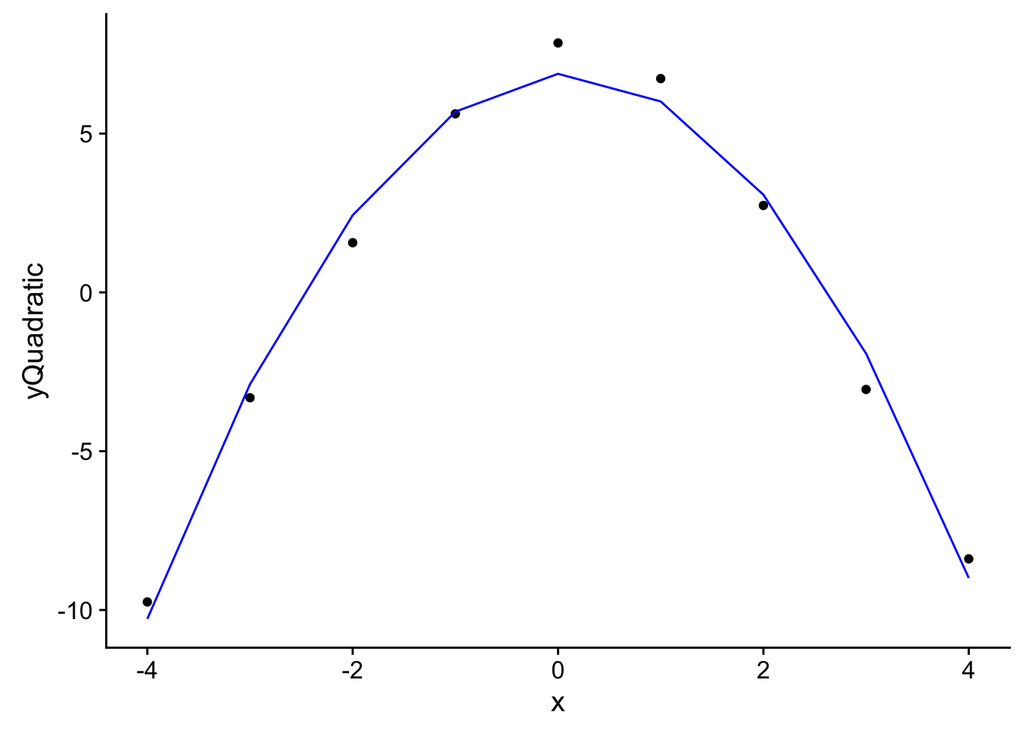

```r
dataDf$predictedQuadratic = predict(lmResultQuadraticModel)

ggplot(dataDf,aes(x,yQuadratic)) +
  geom_point() +
  geom_line(aes(x,predictedQuadratic),color='blue')
```

This clearly fits much better! We can also plot the residuals against the x value:

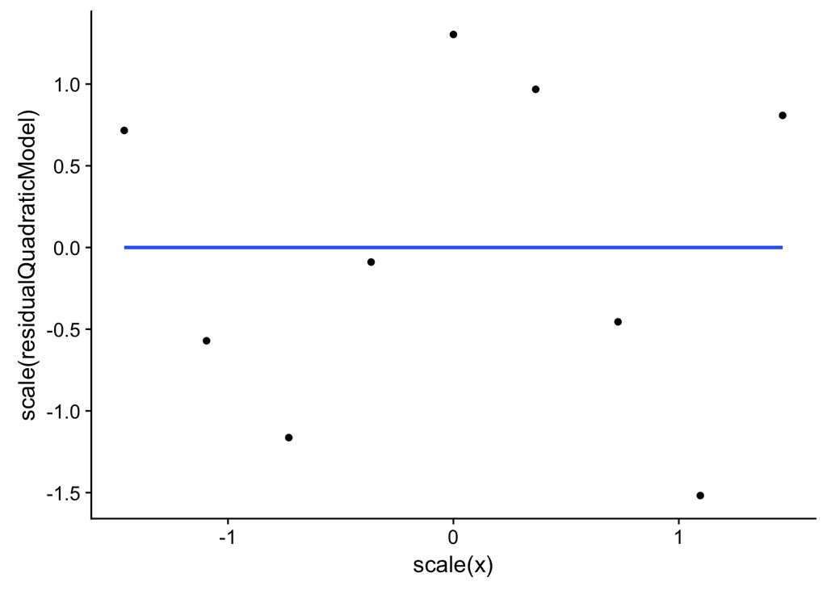

```r
dataDf$residualQuadraticModel=lmResultQuadraticModel$residuals

ggplot(dataDf,aes(scale(x),scale(residualQuadraticModel))) +
  geom_point() + geom_smooth(method='lm',se=FALSE)
```

Now we see that there is no longer any clear relation between the x value and the residuals.

Moral of this story: Always use the right model. How do you know which model is right, you might ask? See the crossvalidation tutorial for more on that.

#### Independence of errors: t-test

Let’s look at an example of how violations of the assumption of independent errors can affect a simple t-test.

Let’s say that we are comparing the relation between drinking soy milk and height in a groups of people from a campus club. Unbeknownst to us, the subjects in our study are members of the Identical Quadruplets club, which consists entirely of identical quadruplets, and each quartet has the same preference for or against soy milk.

Let’s generate the data for group.

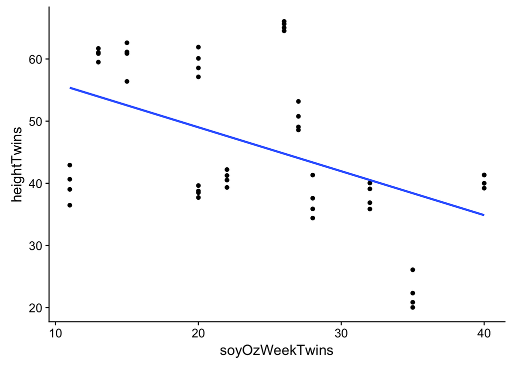

```r
makeSoyData = function(effectSize){
  soyDf=data.frame(soy=c(rep(TRUE,24),rep(FALSE,24)),
                     quartet=kronecker(seq(12),rep(1,4)))
  # create the data for cups per week of soy milk
  quartetSoyOzWeek=ceiling(round(rnorm(12)*12 + 20))
  # set any negative numbers to zero
  quartetSoyOzWeek = ifelse(quartetSoyOzWeek<0,0,quartetSoyOzWeek)

  quartetHeight=ceiling(round(rnorm(12)*10 + 50))

  #create the soy variable for each individual, and a z-scored version of it
  soyDf = soyDf %>%
    mutate(soyOzWeekTwins = kronecker(quartetSoyOzWeek,rep(1,4))) %>%
    mutate(zSoyOzWeekTwins = (soyOzWeekTwins - mean(soyOzWeekTwins))/sd(soyOzWeekTwins))

  soyDf = soyDf %>%
    mutate(heightTwins=kronecker(quartetHeight,rep(1,4)) + soyOzWeekTwins*effectSize + rnorm(nrow(soyDf))*2)

  # fit model to twin data to get residual variance, so we can match to non-twins
  lmResult=lm(heightTwins ~ soyOzWeekTwins,data=soyDf)
  soyDf = soyDf %>%
    mutate(soyOzWeek = sample(soyOzWeekTwins)) %>%
    mutate(height = lmResult$coefficients[1] + soyOzWeek*effectSize + rnorm(nrow(soyDf))*sd(lmResult$residuals))
  return(soyDf)

}
soyDf=makeSoyData(0)
ggplot(soyDf,aes(x=soyOzWeekTwins,y=heightTwins)) +
  geom_point() +
  geom_smooth(method='lm',se=FALSE)
```

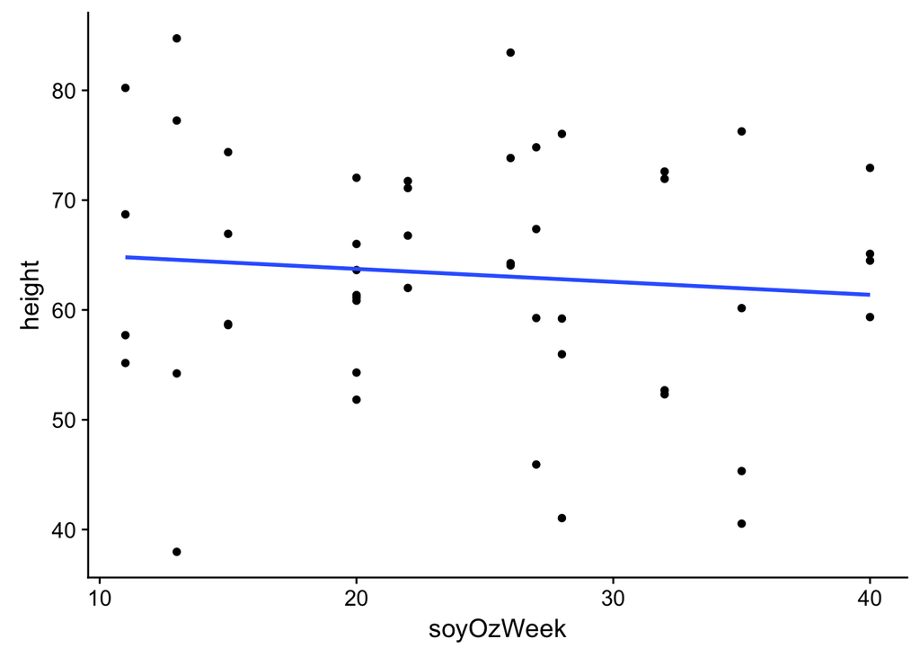

```r
ggplot(soyDf,aes(x=soyOzWeek,y=height)) +
  geom_point() +
  geom_smooth(method='lm',se=FALSE)
```

Let’s plot the residuals from the linear model for the twin data:

```r
lmResult = lm(heightTwins ~ soyOzWeekTwins,data=soyDf)
lmResultIID = lm(height ~ soyOzWeek,data=soyDf)

summary(lmResult)
```

```
##
## Call:
## lm(formula = heightTwins ~ soyOzWeekTwins, data = soyDf)
##
## Residuals:
##     Min      1Q  Median      3Q     Max
## -18.905  -9.059   1.683   7.834  21.284
##
## Coefficients:
##                Estimate Std. Error t value Pr(>|t|)
## (Intercept)     63.1475     4.8324  13.067  < 2e-16 ***
## soyOzWeekTwins  -0.7071     0.1891  -3.739 0.000509 ***
## ---
## Signif. codes:  0 '***' 0.001 '**' 0.01 '*' 0.05 '.' 0.1 ' ' 1
##
## Residual standard error: 11.2 on 46 degrees of freedom
## Multiple R-squared:  0.2331, Adjusted R-squared:  0.2165
## F-statistic: 13.98 on 1 and 46 DF,  p-value: 0.0005095
```

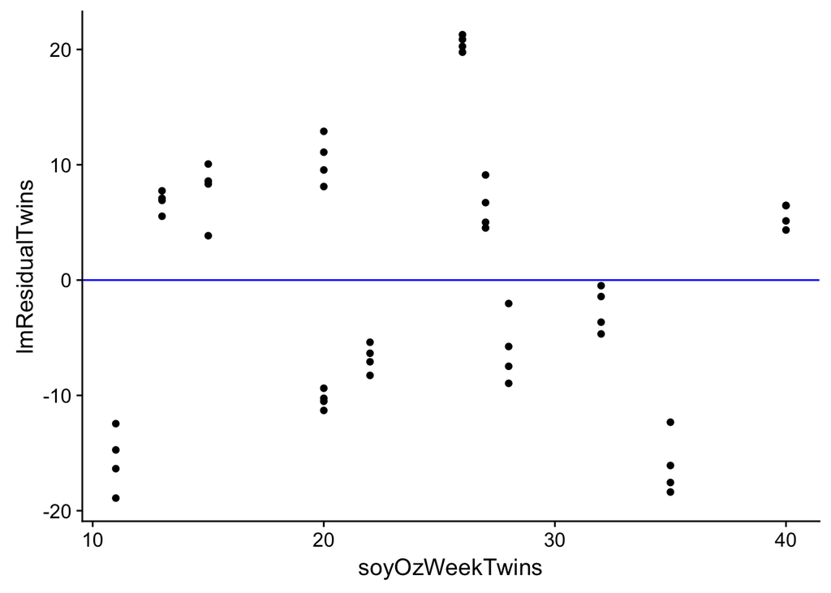

```r
soyDf = soyDf %>%
  mutate(lmResidualTwins = lmResult$residuals,
         lmResidual = lmResultIID$residuals)

ggplot(soyDf,aes(x=soyOzWeekTwins,y=lmResidualTwins)) +
  geom_point() +
  geom_hline(yintercept = 0,color='blue')
```

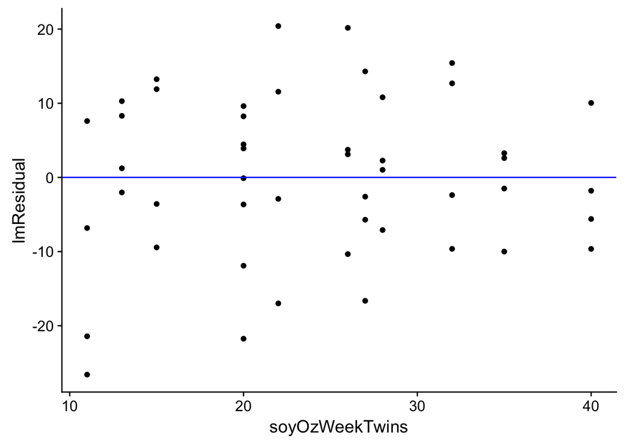

```r
ggplot(soyDf,aes(x=soyOzWeekTwins,y=lmResidual)) +
  geom_point() +
  geom_hline(yintercept = 0,color='blue')
```

Now let’s look at the effects of this factor on our analysis. First, we will create datasets with no signal and look at the prevalence of type I errors.

```r
testTwins = function(){
  soyDf=makeSoyData(0)
  lmResult = lm(heightTwins ~ soyOzWeekTwins,data=soyDf)
  return(summary(lmResult)$coefficients[2,])
}

nullTwinResults = replicate(2500,testTwins())

# check for the proportion of false positive errors

falsePosRateTwins = mean(nullTwinResults[4,]<0.05)
falsePosRateTwins
```

```
## [1] 0.3604
```

```r
testUnrelated = function(){
  soyDf=makeSoyData(0)
  lmResult = lm(height ~ soyOzWeek,data=soyDf)
  return(summary(lmResult)$coefficients[2,])
}

nullUnrelatedResults = replicate(2500,testUnrelated())

# check for the proportion of false positive errors

falsePosRateUnrelated = mean(nullUnrelatedResults[4,]<0.05)
falsePosRateUnrelated
```

```
## [1] 0.05
```

Now let’s do the same thing with actual signal, and see how this affects our ability to detect a difference when it exists (that is, our *power*).

```r
testTwins = function(){
  soyDf=makeSoyData(0.5)
  lmResult = lm(heightTwins ~ soyOzWeekTwins,data=soyDf)
  return(summary(lmResult)$coefficients[2,])
}

posTwinResults = replicate(2500,testTwins())

# check for the proportion of false positive errors

powerTwins = mean(posTwinResults[,4]<0.05)
powerTwins
```

```
## [1] 0.25
```

```r
betaEstTwins=mean(posTwinResults[,1])
betaEstTwins
```

```
## [1] 1.92227
```

```r
testUnrelated = function(){
  soyDf=makeSoyData(0.5)
  lmResult = lm(height ~ soyOzWeek,data=soyDf)
  return(summary(lmResult)$coefficients[2,])
}

posUnrelatedResults = replicate(2500,testUnrelated())

# check for the proportion of false positive errors

powerUnrelated = mean(posUnrelatedResults[,4]<0.05)
powerUnrelated
```

```
## [1] 0.25
```

### Crossvalidation

One of our goals in statistics and machine learning is to able to make predictions about new data given some existing dataset. We have already seen (in Session 5) how a more complex model will always fit our specific dataset better, but will often cause the model to do a worse job making predictions about new datasets. In this tutorial you will see how we can use a concept from machine learning called “cross-validation” to determine how well our model would fit on new data, even when we only have one dataset.

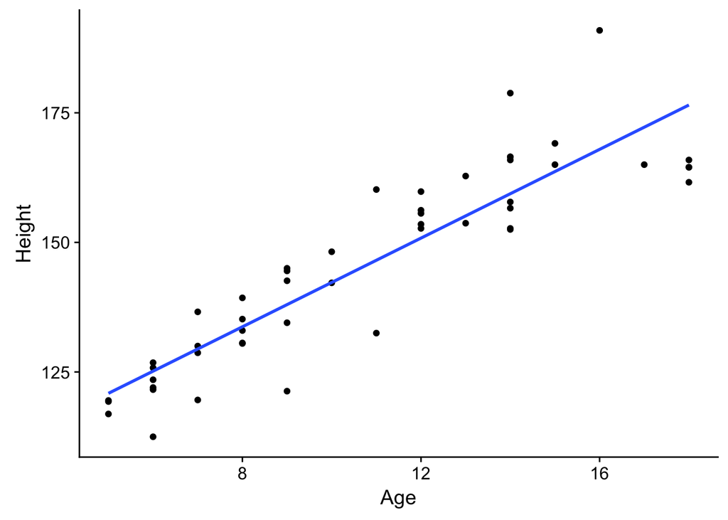

```r
library(NHANES)
library(dplyr)
library(ggplot2)


set.seed(123456789)
sampleSize=50
NHANES_sample = NHANES %>%
  unique() %>%
  filter(Age>4 & Age<19 & !is.na(Height) & !is.na(Gender)) %>%
  select(Age,Height,Gender) %>%
  sample_n(sampleSize)

ggplot(NHANES_sample,aes(Age,Height)) +
  geom_point() +
  geom_smooth(method='lm',se=FALSE)
```

We can fit a model to the full dataset, using the lm() function. Let’s start with a simple linear model:

```r
lmResultLinear = lm(Height ~ Age + Gender,data=NHANES_sample)
summary(lmResultLinear)
```

```
##
## Call:
## lm(formula = Height ~ Age + Gender, data = NHANES_sample)
##
## Residuals:
##     Min      1Q  Median      3Q     Max
## -16.986  -3.786  -0.071   5.854  22.507
##
## Coefficients:
##             Estimate Std. Error t value Pr(>|t|)
## (Intercept)  98.9632     4.0737  24.293   <2e-16 ***
## Age           4.3009     0.3167  13.579   <2e-16 ***
## Gendermale    0.6149     2.4785   0.248    0.805
## ---
## Signif. codes:  0 '***' 0.001 '**' 0.01 '*' 0.05 '.' 0.1 ' ' 1
##
## Residual standard error: 8.366 on 47 degrees of freedom
## Multiple R-squared:  0.8089, Adjusted R-squared:  0.8008
## F-statistic: 99.48 on 2 and 47 DF,  p-value: < 2.2e-16
```

```r
MSElinear = mean((NHANES_sample$Height -lmResultLinear$fitted.values)**2)
MSElinear
```

```
## [1] 65.79235
```

What happens now if we take a many new samples from NHANES and try to predict Height of those individuals using the same model?

```r
sampleFit = function(){
  NHANES_sample2 =NHANES %>%
    unique() %>%
    filter(Age>4 & Age<19 & !is.na(Height) & !is.na(Gender)) %>%
    select(Age,Height,Gender) %>%
    sample_n(sampleSize)
  mse=mean((NHANES_sample2$Height -predict(lmResultLinear,newdata=NHANES_sample2))**2)
}

MSElinearNew = replicate(100,sampleFit())
mean(MSElinearNew)
```

```
## [1] 82.99839
```

Here we see that the model still predicts height well, but slightly less well than it did for the data that the model was fitted to.

We would like to be able to determine how well the model will fit with new data (which we also refer to as “generalization”), so that we can know how much faith to have in our predictions, even if we don’t have a whole new dataset to test it on, like we had above. We can use the concept of cross-validation to do this.

In cross-validation, we split our dataset into two parts that we call a “training set” (which is used to fit or “train” the model) and a “testing set” (which is used to to test or validate the model). We do this repeatedly so that each data point will end up in one testing set. A simple version of this is called “leave one out” cross-validation, which works like it sounds: We march through all of the observations,in each case leaving out one observation and then using the model fitted with the remaining data to predict the outcome for the left-out (“test”) observation. Let’s see how that would work for our sample.

```r
# add an index that we can use to loop over
NHANES_sample = NHANES_sample %>%
  mutate(ID = seq(1:sampleSize),
         predictedLOO=NA)

# create a function that runs the model on the training data and returns the predicted value
cvPredict = function(testDf,dataDf){
  trainDf = dataDf %>% filter(ID != testDf$ID)
  model = lm(Height ~ Age + Gender ,data=trainDf)
  testDf$predictedLOO = predict(model,newdata=testDf)
  return(testDf)
}

cvPredictions = NHANES_sample %>%
  group_by(ID) %>%
  do(cvPredict(.,NHANES_sample))

MSEloo = mean((cvPredictions$Height-cvPredictions$predictedLOO)**2)
MSEloo
```

```
## [1] 75.69173
```

This shows that our model does a good job of predicting height from age and gender, even on individuals who were not included in the fitting of the model. In fact, it only does a tiny bit worse than it did on the original data.

### Model selection using cross validation

One of the ways that we can use cross validation is to determine the right model. Remember from before that a more complex model will always fit the data better, because it can adapt to the specific data points. This will improve the fit to the specific dataset, but will actually make the model *worse* at generalization, because it will be *overfitted* to the original dataset. Cross-validation provides a way to prevent this.

Let’s say that we have a dataset and we don’t know what the right model is; it could be linear, quadratic, or cubic. Let’s generate some data with each of these patterns.

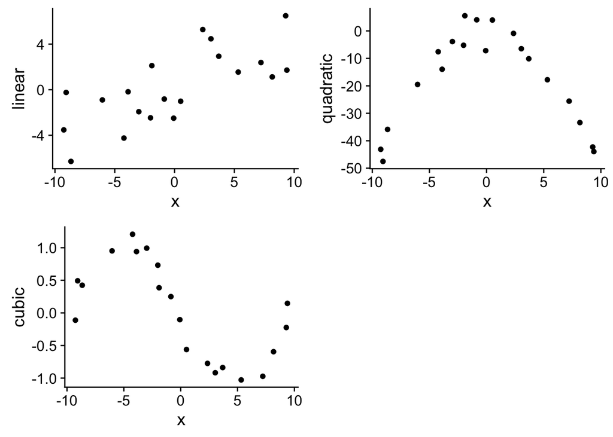

```r
# show linear, quadratic, and cubic fits to a dataset
nPoints=20
noiseSD=3
cubicPts= sin(seq(0,2*pi,length.out=nPoints))
dataDf = data.frame(x=runif(nPoints)*20) %>%
  mutate(x=x-mean(x)) %>%
  arrange(x) %>%
  mutate(linear = x*0.5 + rnorm(nPoints)*noiseSD) %>%
  mutate(quadratic = (x**2)*-0.5 + rnorm(nPoints)*noiseSD) %>%
  mutate(cubic = cubicPts  + rnorm(nPoints)*0.1)

library(cowplot)

p1=ggplot(dataDf,aes(x,linear)) + geom_point()
p2=ggplot(dataDf,aes(x,quadratic)) + geom_point()
p3=ggplot(dataDf,aes(x,cubic)) + geom_point()
plot_grid(p1,p2,p3)
```

Now let’s fit all three models to each dataset. We can do this using the poly() function in R, which will generate a polynomial of a given order. The models look like this:

Linear (model order 1):

$$y = x*\beta_1 + intercept$$
]

Quadratic (model order 2):

$$y = x*\beta_1 + x^2*\beta_2 + intercept$$
]

Cubic (model order 3):

$$y = x*\beta_1 + x^2*\beta_2 + x^3*\beta_3 + intercept$$
]

Let’s fit them all using lm() - see https://www.r-bloggers.com/fitting-polynomial-regression-in-r/ for more on this:

```r
fitModel = function(modelDf,dataDf){
  modelFit = lm(sprintf('%s ~ poly(x,%d)',modelDf$data,modelDf$modelOrder),data=dataDf)
  modelDf$MSE = mean(modelFit$residuals**2)
  return(modelDf)
}

modelDf = expand.grid(data=c('linear','quadratic','cubic'),modelOrder=seq(1,3))
modelDf = modelDf %>% group_by(data,modelOrder) %>% do(fitModel(.,dataDf))
modelDf
```

| data | modelOrder | MSE |
| --- | --- | --- |
| linear | 1 | 4.86223223 |
| linear | 2 | 4.84885909 |
| linear | 3 | 4.58470297 |
| quadratic | 1 | 299.22890561 |
| quadratic | 2 | 13.13476844 |
| quadratic | 3 | 12.74408307 |
| cubic | 1 | 0.30820483 |
| cubic | 2 | 0.30820227 |
| cubic | 3 | 0.02489371 |

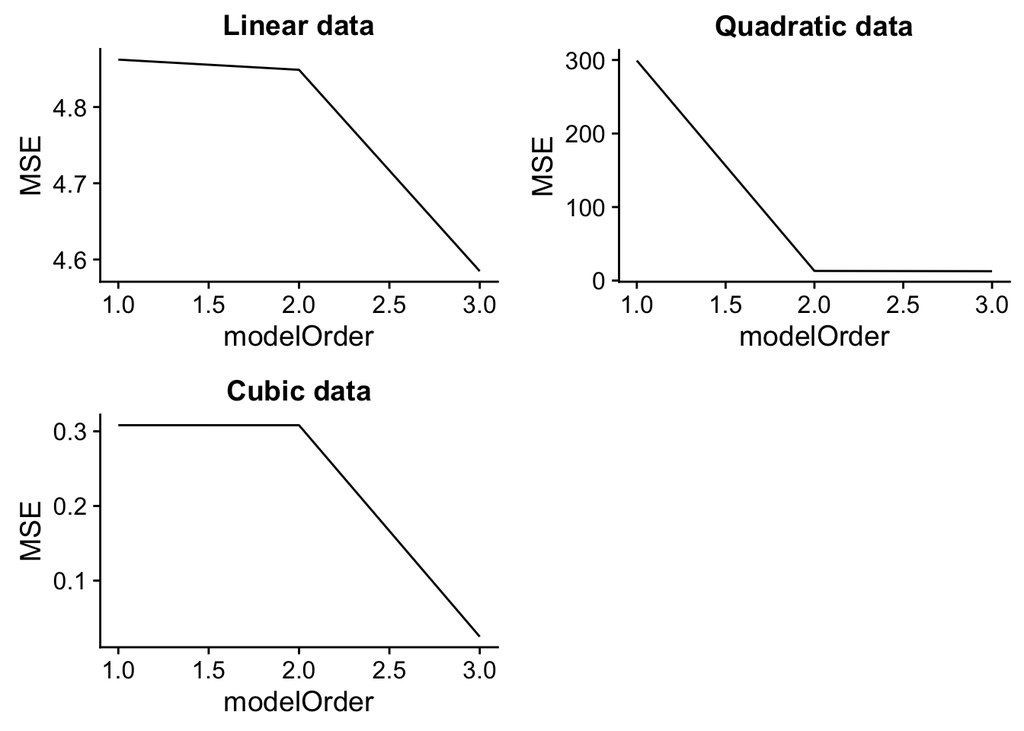

```r
p1=ggplot(modelDf %>% filter(data=='linear'),aes(modelOrder,MSE)) +
  geom_line() +
  ggtitle('Linear data')
p2=ggplot(modelDf %>% filter(data=='quadratic'),aes(modelOrder,MSE)) +
  geom_line() +
  ggtitle('Quadratic data')
p3=ggplot(modelDf %>% filter(data=='cubic'),aes(modelOrder,MSE)) +
  geom_line() +
  ggtitle('Cubic data')

plot_grid(p1,p2,p3)
```

As we saw in Lecture 5, the error is always lower for the more complex model, regardless of whether it’s actually the right model or not. Let’s look at the linear data to see what is going on:

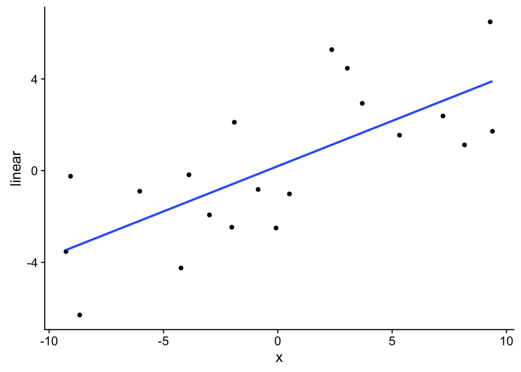

```r
ggplot(dataDf,aes(x,linear)) +
  geom_point() +
  geom_smooth(method=lm,formula='y ~ poly(x,1)',se=FALSE)
```

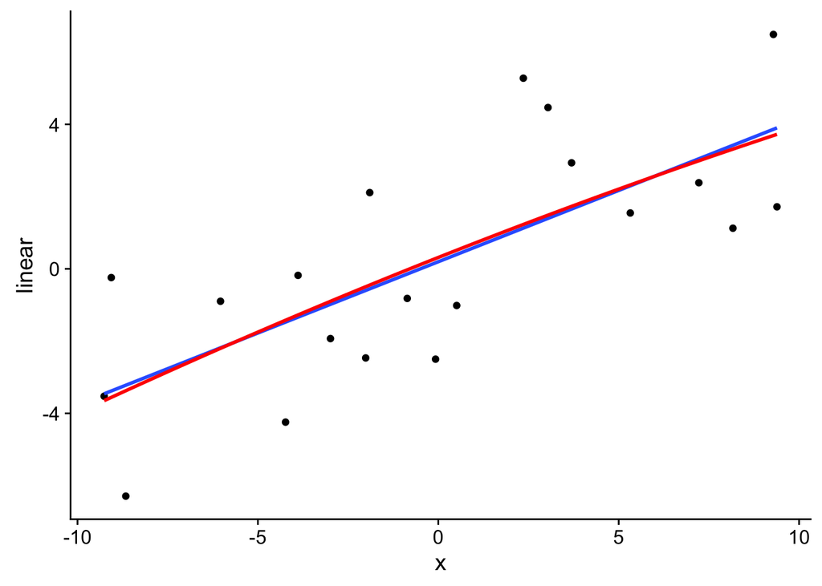

```r
ggplot(dataDf,aes(x,linear)) +
  geom_point() +
  geom_smooth(method=lm,formula='y ~ poly(x,1)',se=FALSE) +
  geom_smooth(method=lm,formula='y ~ poly(x,2)',se=FALSE,color='red')
```

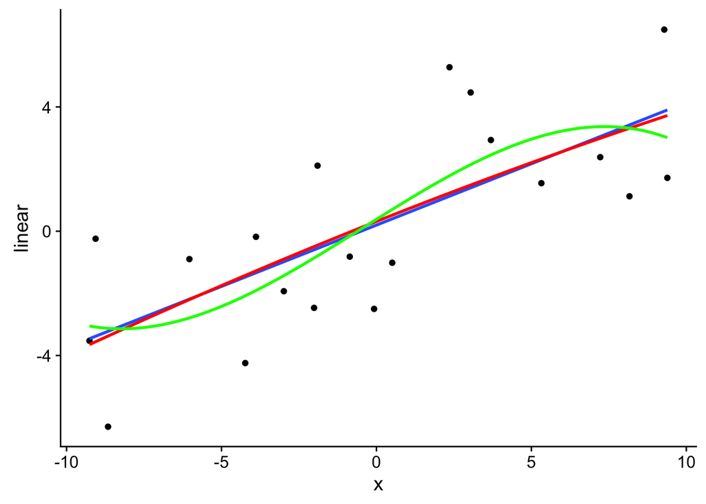

```r
ggplot(dataDf,aes(x,linear)) +
  geom_point() +
  geom_smooth(method=lm,formula='y ~ poly(x,1)',se=FALSE) +
  geom_smooth(method=lm,formula='y ~ poly(x,2)',se=FALSE,color='red') +
  geom_smooth(method=lm,formula='y ~ poly(x,3)',se=FALSE,color='green')
```

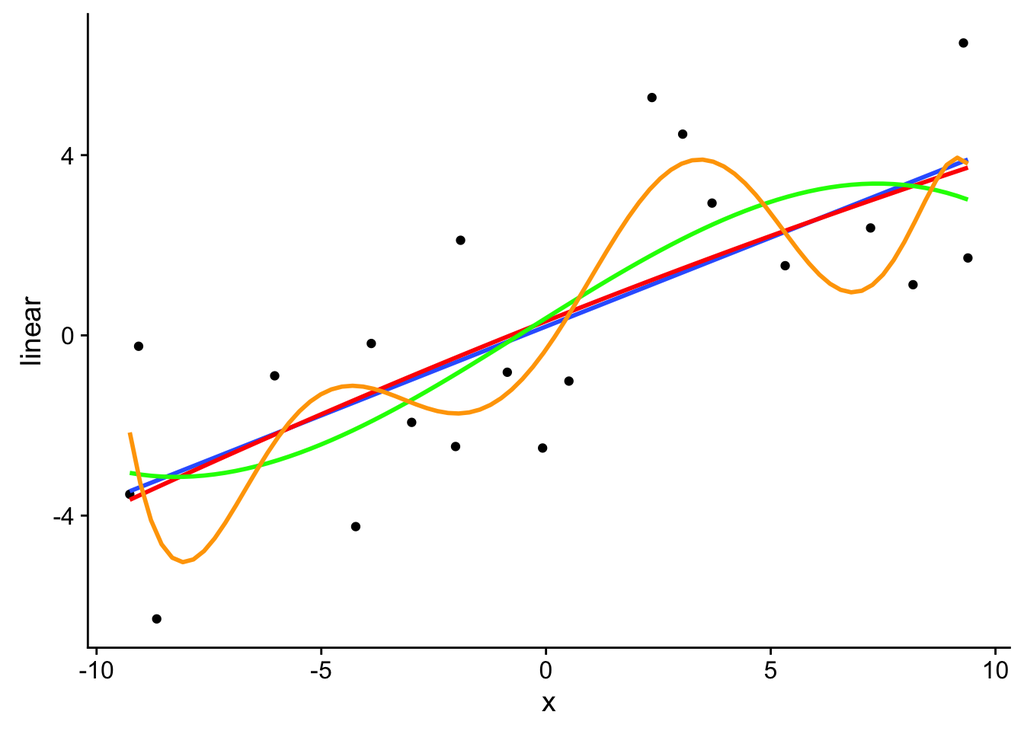

```r
ggplot(dataDf,aes(x,linear)) +
  geom_point() +
  geom_smooth(method=lm,formula='y ~ poly(x,1)',se=FALSE) +
  geom_smooth(method=lm,formula='y ~ poly(x,2)',se=FALSE,color='red') +
  geom_smooth(method=lm,formula='y ~ poly(x,3)',se=FALSE,color='green') +
  geom_smooth(method=lm,formula='y ~ poly(x,8)',se=FALSE,color='orange')
```

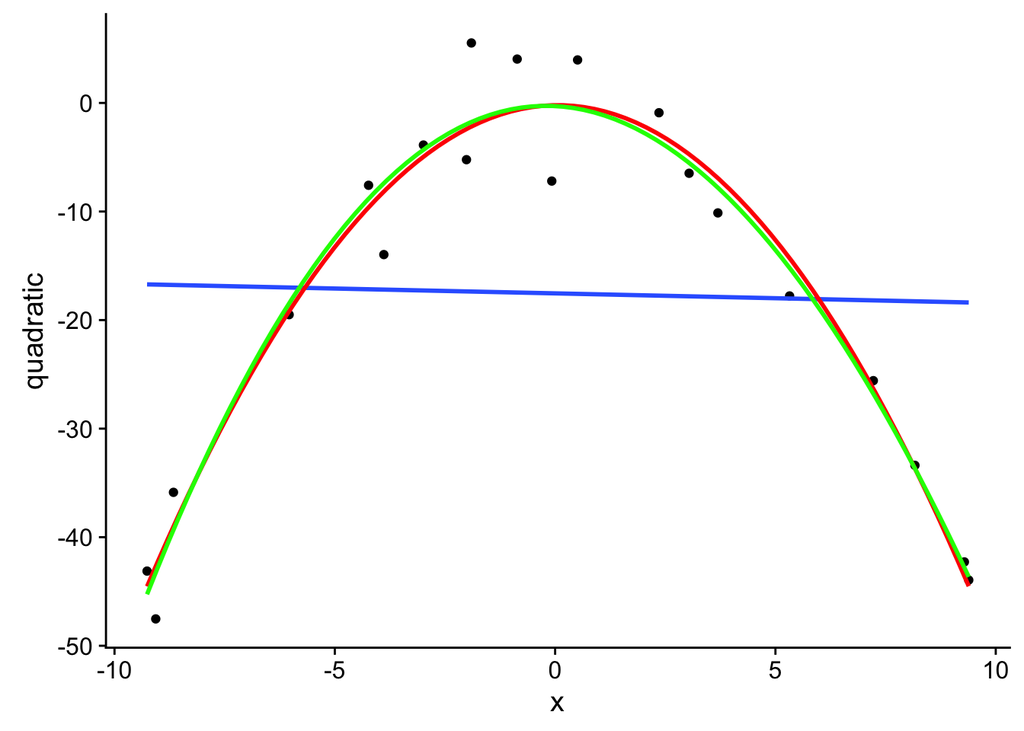

```r
ggplot(dataDf,aes(x,quadratic)) +
  geom_point() +
  geom_smooth(method=lm,formula='y ~ poly(x,1)',se=FALSE) +
  geom_smooth(method=lm,formula='y ~ poly(x,2)',se=FALSE,color='red') +
  geom_smooth(method=lm,formula='y ~ poly(x,3)',se=FALSE,color='green')
```

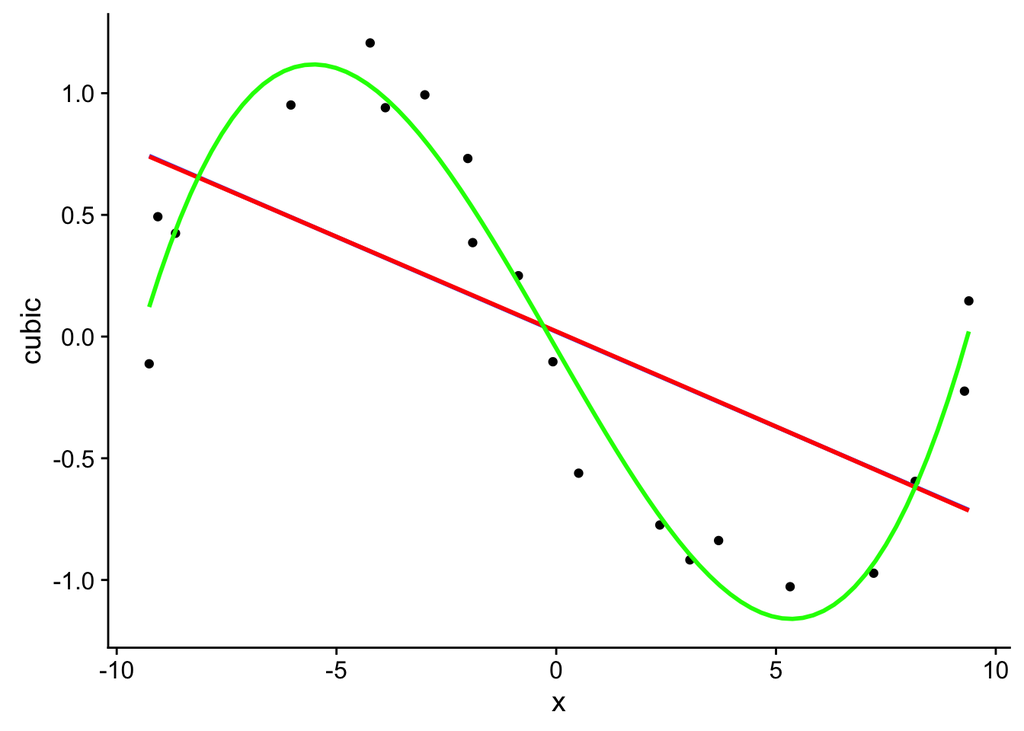

```r
ggplot(dataDf,aes(x,cubic)) +
  geom_point() +
  geom_smooth(method=lm,formula='y ~ poly(x,1)',se=FALSE) +
  geom_smooth(method=lm,formula='y ~ poly(x,2)',se=FALSE,color='red') +
  geom_smooth(method=lm,formula='y ~ poly(x,3)',se=FALSE,color='green')
```

We see that the higher order models are fitting the noise rather than the signal in the dataset for the datasets where there is no nonlinear signal present. Conversely, the linear model *underfits* on the data with the quadratic and cubic signal.

How can we decide which model is actually the right one? Cross-validation gives us a way to do this. Instead of deciding based on how well the model fits to the data that it was created with, we instead fit the model to part of the data but then test it on a different part. To keep things simple we will use our leave-one-out procedure that we discussed above; this is usually not the best way to perform crossvalidation, but it’s perfectly legitimate.

First let’s setup a simple version, and then we will apply it to the data created above.

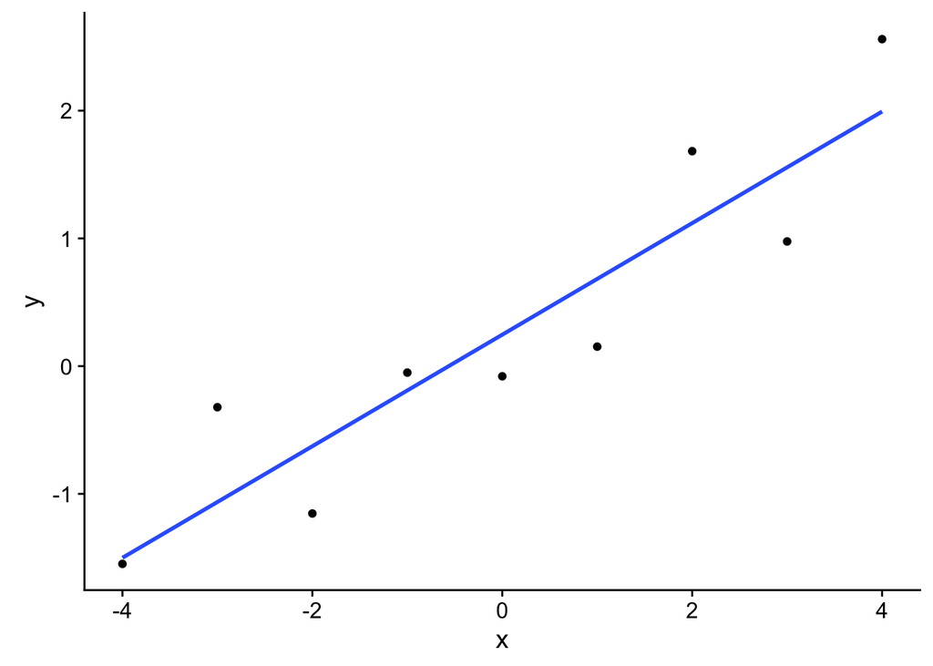

```r
cvDf = data.frame(x=seq(-4,4,1)) %>%
  mutate(y=x*0.5 + rnorm(9)*0.5)
cvDf = cvDf %>%
  mutate(ID=seq(1,9)) %>%
  mutate(prediction=NA,slope=NA,intercept=NA)

ggplot(cvDf,aes(x,y)) +
  geom_point() +
  geom_smooth(method='lm',se=FALSE)
```

```r
cvDf
```

| x | y | ID | prediction | slope | intercept |
| --- | --- | --- | --- | --- | --- |
| -4 | -1.54790855 | 1 | NA | NA | NA |
| -3 | -0.32148867 | 2 | NA | NA | NA |
| -2 | -1.15362824 | 3 | NA | NA | NA |
| -1 | -0.05067826 | 4 | NA | NA | NA |
| 0 | -0.07957092 | 5 | NA | NA | NA |
| 1 | 0.15273472 | 6 | NA | NA | NA |
| 2 | 1.68286638 | 7 | NA | NA | NA |
| 3 | 0.97608662 | 8 | NA | NA | NA |
| 4 | 2.56002711 | 9 | NA | NA | NA |

To perform cross validation on this dataset, we take each datapoint and fit the model using the remainder of the data points, and then use the model to make a prediction for the left-out data point.

```r
cvDf = cvDf
for (i in 1:nrow(cvDf)) {
  # set up training and test data frames
  trainingDf=cvDf %>% filter(ID != i)
  testDf = cvDf %>% filter(ID == i)
   # fit model to training data
  lmResult = lm(y ~ x, data=trainingDf)
  cvDf$prediction[i] = predict(lmResult,newdata=testDf)
  cvDf$intercept[i] = lmResult$coefficients[1]
  cvDf$slope[i] = lmResult$coefficients[2]


}
```

Make figures for lecture

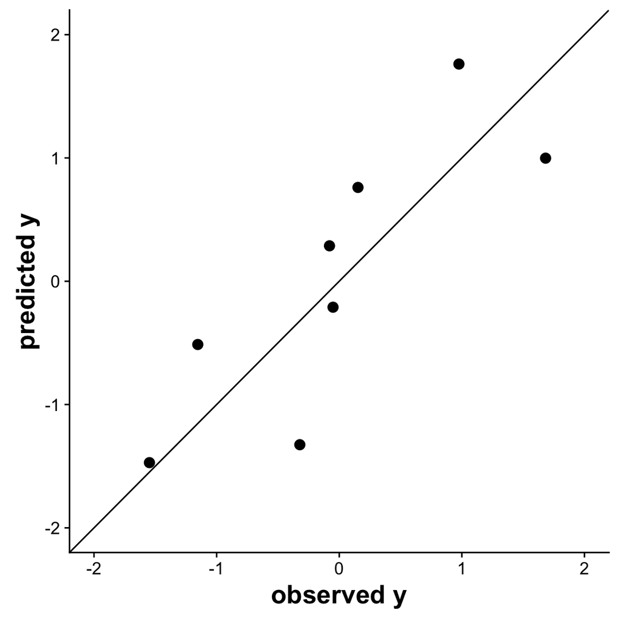

```r
for (i in 1:nrow(cvDf)) {
  ggplot(cvDf,aes(x,y)) +
    geom_point() +
    annotate('point',x=cvDf$x[i],y=cvDf$y[i],color='red',size=3) +
    geom_abline(slope=cvDf$slope[i],intercept=cvDf$intercept[i],color='blue') +
    xlim(-4.5,4.5) + ylim(-4.5,4.5) +
    annotate('point',x=cvDf$x[i],y=cvDf$prediction[i],color='green',size=3)
  ggsave(sprintf('cv_demo/point%d.png',i),width=6,height=6)
}
ggplot(cvDf,aes(y,prediction)) +
  geom_point(size=3) +
  xlim(-2,2) + ylim(-2,2) +
  geom_abline(slope=1,intercept=0) +
  xlab('observed y') + ylab('predicted y') +
  theme(axis.text=element_text(size=12), axis.title=element_text(size=18,face="bold"))
```

```r
lmResultFullData = lm(y~x, cvDf)
fullDataRMSE = sqrt(mean(lmResultFullData$residuals**2))
fullDataRMSE
```

```
## [1] 0.4958413
```

```r
cvDf = cvDf %>% mutate(predictionResidual = prediction - y)
predictionRMSE = sqrt(mean(cvDf$predictionResidual**2))
predictionRMSE
```

```
## [1] 0.6558042
```

Take 100 samples from the same generating model and look at the fit of the model to the new data.

```r
testNewSample = function(lmResult){
  cvDfNew = data.frame(x=seq(-4,4,1)) %>%
    mutate(y=x*0.5 + rnorm(9)*0.5)
pred=predict(lmResult,cvDfNew)
cvDfNew = cvDfNew %>% mutate(predictionError=pred-y)
return(sqrt(mean(cvDfNew$predictionError**2)))
}

newSampleRMSE=replicate(100,testNewSample(lmResultFullData))
mean(newSampleRMSE)
```

```
## [1] 0.5565273
```

Now we apply it to the data from above.

```r
cvPredict2 = function(testDf,dataDf,modelOrder,datatype){

  trainDf = dataDf %>% filter(ID != testDf$ID)
  model = lm(sprintf('%s ~ poly(x,%d)',datatype,modelOrder),data=trainDf)
  testDf$predictedLOO = predict(model,newdata=testDf)
  return(testDf)
}


fitModelLOO = function(modelDf,dataDf){
  dataDf=dataDf %>% mutate(ID=seq(1,nrow(dataDf)))
  cvOutput = dataDf %>% group_by(ID) %>% do(cvPredict2(.,dataDf,modelDf$modelOrder,modelDf$data))
  modelDf$MSEloo = mean((cvOutput$predictedLOO - cvOutput[,as.character(modelDf[1,]$data)])**2)
  return(modelDf)
}

outputLOO = modelDf %>% group_by(data,modelOrder) %>% do(fitModelLOO(.,dataDf))
```

Let’s plot the results to see how it turned out:

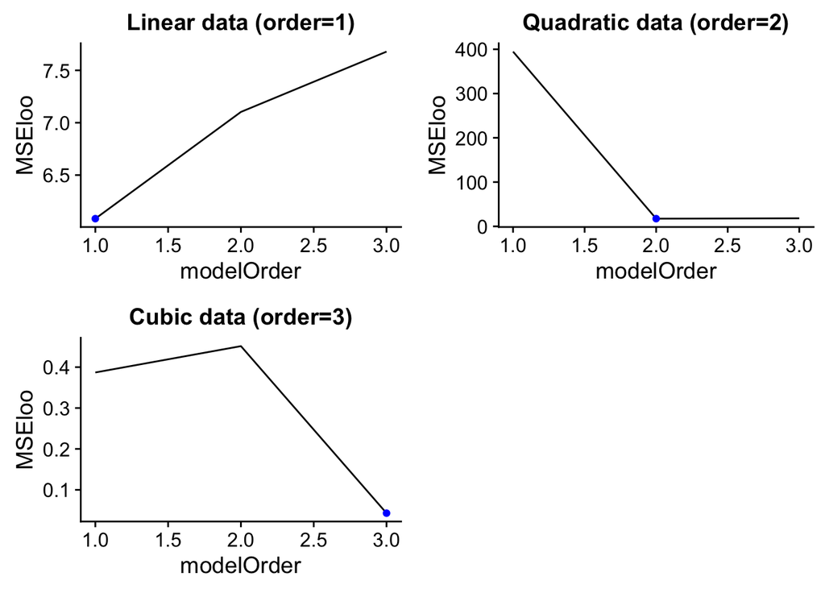

```r
minMSE = outputLOO %>% group_by(data) %>% summarize(minMSE=min(MSEloo),bestModelOrder=which(MSEloo==min(MSEloo)))
p1=ggplot(outputLOO %>% filter(data=='linear'),aes(modelOrder,MSEloo)) +
  geom_line() +
  ggtitle('Linear data (order=1)') +
  annotate('point',x=minMSE$bestModelOrder[1],y=minMSE$minMSE[1],color='blue')

p2=ggplot(outputLOO %>% filter(data=='quadratic'),aes(modelOrder,MSEloo)) +
  geom_line() +
  ggtitle('Quadratic data (order=2)') +
  annotate('point',x=minMSE$bestModelOrder[2],y=minMSE$minMSE[2],color='blue')

p3=ggplot(outputLOO %>% filter(data=='cubic'),aes(modelOrder,MSEloo)) +
  geom_line() +
  ggtitle('Cubic data (order=3)') +
  annotate('point',x=minMSE$bestModelOrder[3],y=minMSE$minMSE[3],color='blue')


plot_grid(p1,p2,p3)
```

We see that in each case, the MSE for the held-out data was lowest for the model that was properly matched to the data.